# Tidy Tuesday Week 16

rolldown with my homies: BBC scores of hip-hop tracks

Gavin Fay

2020-04-16

# 1 TidyTuesday16

For this week’s **#TIdyTuesday** I wanted to try out scrollytelling, with `@xieyihui`’s `rolldown` package.

I investigated the best rap artists dataset, containing ranks from BBC Music on critics’ favorite hip-hop tracks.

Data & TidyTuesday:  
https://github.com/rfordatascience/tidytuesday/blob/master/data/2020/2020-04-14/readme.md

100+ critics ranked their favorite tracks, and then these ranks were aggregated to give each track an overall point score based on how many times they received rankings.

## 1.1 When were the best hip-hop tracks released?

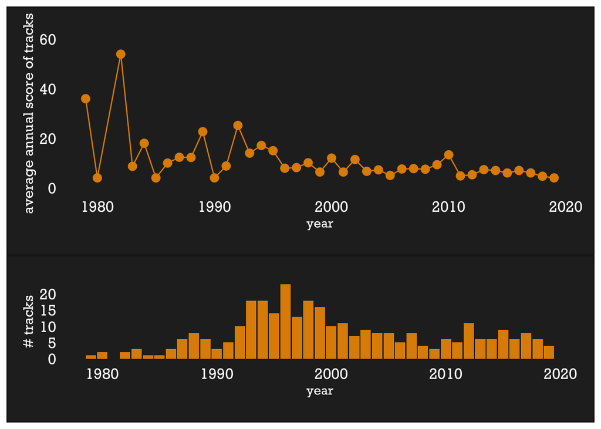

# 2 Which tracks were ranked the highest?

## 2.1 Overall

The early 90s produced the best tracks. Duh.

Table 2.1: Top ten highest ranking tracks

| year | artist | title | points |
| --- | --- | --- | --- |
| 1994 | The Notorious B.I.G. | Juicy | 140 |
| 1989 | Public Enemy | Fight The Power | 100 |
| 1995 | Mobb Deep | Shook Ones (Part II) | 94 |
| 1982 | Grandmaster Flash & The Furious Five | The Message | 90 |
| 1992 | Dr Dre ft. Snoop Doggy Dogg | Nuthin’ But A ‘G’ Thang | 84 |
| 1993 | Wu-Tang Clan | C.R.E.A.M. | 62 |
| 1993 | Souls of Mischief | 93 ’Til Infinity | 50 |
| 1992 | The Pharcyde | Passin’ Me By | 48 |
| 1994 | Nas | N.Y. State Of Mind | 46 |
| 1995 | 2Pac | Dear Mama | 42 |

## 2.2 Best tracks by year

Looking at the highest scoring tracks by year we see many years where of the songs receiving ranks, female artists had the best track of the year, despite so few tracks in those receiving rankings being by women (as analyzed in Simon Jocker’s post.

### 2.2.1 for 2000-2019

Table 2.2: What were the highest ranked songs each year?

| year | artist | title | points |
| --- | --- | --- | --- |
| 2019 | BIG K.R.I.T | Learned from Texas | 6 |
| 2018 | Stogie T | God’s Eye | 8 |
| 2017 | Cardi B | Bodak Yellow | 10 |
| 2016 | Black Vulcanite | How To Rap About Africa | 10 |
| 2015 | Kendrick Lamar | Alright | 22 |
| 2014 | Future | Codeine Crazy | 14 |
| 2013 | Kanye West | Blood On The Leaves | 14 |
| 2012 | Kendrick Lamar | m.A.A.d. city | 12 |
| 2011 | Nicki Minaj | Super Bass | 8 |
| 2010 | Kanye West ft. Pusha T | Runaway | 38 |
| 2009 | Jay Electronica | Exhibit C | 18 |
| 2008 | Lil Wayne | A Milli | 12 |
| 2007 | UGK ft. OutKast | International Players Anthem | 28 |
| 2006 | Lupe Fiasco | Kick Push | 10 |
| 2005 | Missy Elliot ft. Ciara and Fatman Scoop | Lose Control | 10 |
| 2004 | Kanye West | Jesus Walks | 24 |
| 2003 | 50 Cent | In Da Club | 14 |
| 2002 | Eminem | Lose Yourself | 28 |
| 2001 | Missy Elliott | Get Ur Freak On | 10 |
| 2000 | OutKast | B.O.B. | 32 |

### 2.2.2 and for 1979-1999

Table 2.3: What were the highest ranked songs each year?

| year | artist | title | points |
| --- | --- | --- | --- |
| 1999 | DMX | Party Up (Up In Here) | 14 |
| 1998 | Lauryn Hill | Doo Wop (That Thing) | 28 |
| 1997 | Wu-Tang Clan | Triumph | 18 |
| 1996 | The Fugees | Ready Or Not | 22 |
| 1995 | Mobb Deep | Shook Ones (Part II) | 94 |
| 1994 | The Notorious B.I.G. | Juicy | 140 |
| 1993 | Wu-Tang Clan | C.R.E.A.M. | 62 |
| 1992 | Dr Dre ft. Snoop Doggy Dogg | Nuthin’ But A ‘G’ Thang | 84 |
| 1991 | Geto Boys | Mind Playing Tricks On Me | 12 |
| 1990 | A Tribe Called Quest | Bonita Applebum | 6 |
| 1989 | Public Enemy | Fight The Power | 100 |
| 1988 | NWA | Fuck Tha Police | 32 |
| 1987 | Eric B & Rakim | Paid In Full | 36 |
| 1986 | Run DMC | Walk This Way | 18 |
| 1985 | Doug E Fresh & The Get Fresh Crew | La Di Da Di | 4 |
| 1984 | Run DMC | Sucker MCs | 18 |
| 1983 | Double Trouble | Double Trouble At The Amphitheatre | 10 |
| 1982 | Grandmaster Flash & The Furious Five | The Message | 90 |
| 1980 | Tanya ‘Sweet Tee’ Winley | Vicious Rap | 6 |
| 1979 | Sugarhill Gang | Rapper’s Delight | 36 |

# 3 More women represented over time?

We see that the chance that the highest scoring track in a year was by a female artist almost doubles over the time series, from 9% to 16%.

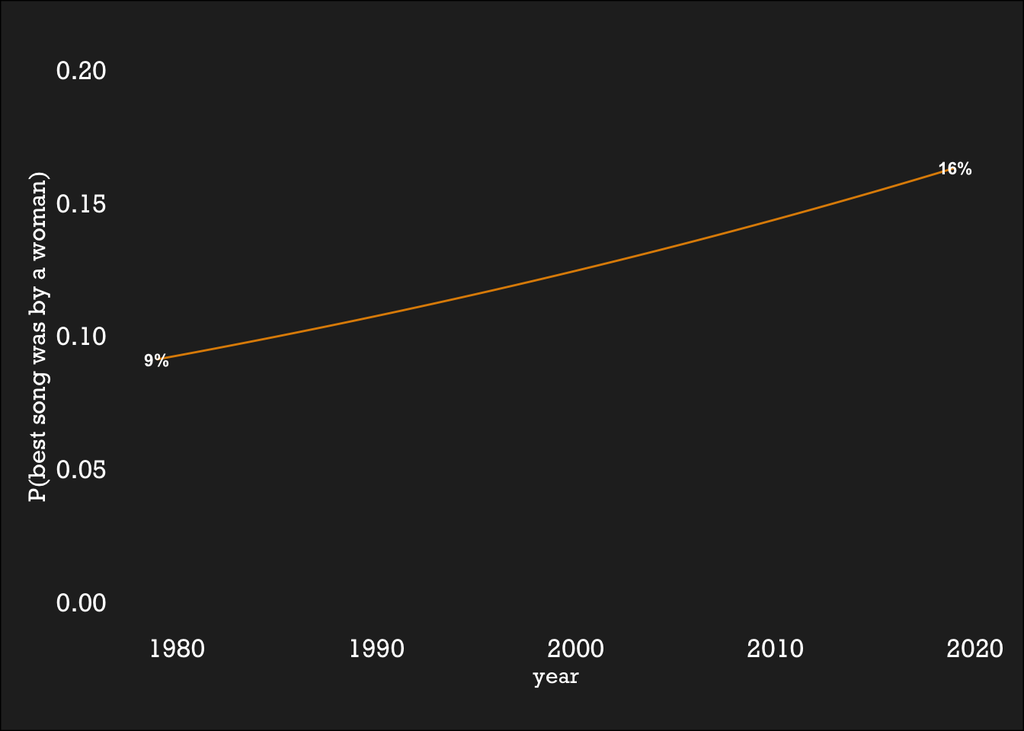

# 4 Positivity

Applying sentiment analysis to the words in the titles of tracks, we see that 90s track titles contained more positive words than tracks receiving votes released in other decades.  
Sentiments of positivity and joy were relatively more frequent in the 90s, as were words of SURPRISE!

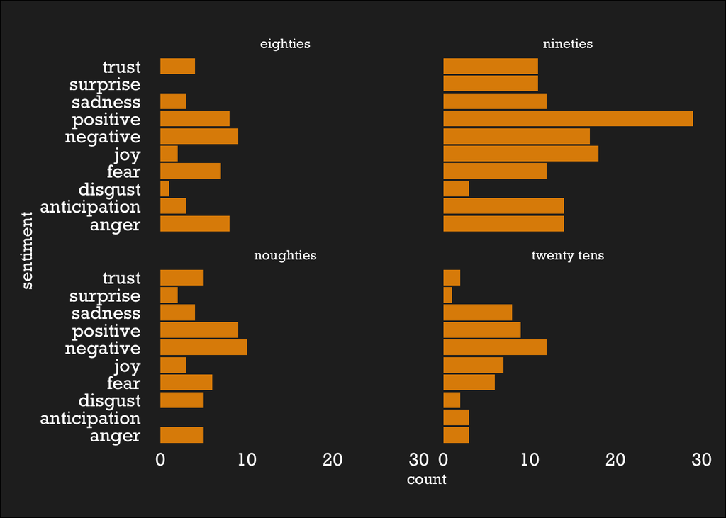